# Count Data Analysis

Associations and other tests

Jyotishka Datta

Virginia Tech

20 October 2026

## Recap

- Drawbacks of Pearson’s correlation coefficient?
- Nonparametric measures of association between a pair of **continuous** variables:
  1. Spearman’s rank correlation.
  2. Kendall’s tau.
- Today we will start discussing association between two **qualitative** variables.

## Recap in R

The three coefficients on the `cars` data, for comparison:

```r
sapply(c("pearson", "spearman", "kendall"), function(m)
  cor(cars$speed, cars$dist, method = m))
```

```
#>   pearson  spearman   kendall
#> 0.8068949 0.8303568 0.6689901
```

Pearson’s $r$ measures only the **linear** part; the two rank-based measures are invariant to any monotone transformation of either variable. None of them applies when the variables are *categories* rather than numbers.

# Introduction and basic idea

## Introduction

- Main goal: basic analysis of data presented in a two-way table with $r$ rows and $k$ columns, called an $r \times k$ **contingency table**, where the cell counts refer to the number of sample observations that have certain cross characteristics.
- Here we have a test for the null hypothesis that the characteristics are **independent** or have **no association**.
- We will also calculate the **contingency coefficient** or the **phi coefficient** to measure the degree of association or dependence.

## Introduction (contd.)

- A special case is the analysis of $k \times 2$ contingency tables. We will present some special results for that.
- Another special case of contingency tables is the $2 \times 2$ table with fixed row and column totals: **Fisher’s exact test**.
- We also cover **McNemar’s test** for comparing two probabilities of success based on paired or dependent samples.

## Example 1: Music and Wine

- Market researchers know that background music can influence the mood and purchasing behavior of customers.
- One study compared 3 treatments: no music, French accordion music, and Italian string music.
- Under each condition, the researchers recorded the number of bottles of French, Italian, and other wine purchased.

## Example 1 continued

The data can be presented as a $3 \times 3$ table (contingency table): total 243 bottles were sold.

Table 1

```r
wine <- matrix(
  c(30, 39, 30,
    11,  1, 19,
    43, 35, 35),
  nrow = 3, byrow = TRUE,
  dimnames = list(Wine  = c("French", "Italian", "Other"),
                  Music = c("None", "French", "Italian"))
)
wine
```

```
#>          Music
#> Wine      None French Italian
#>   French    30     39      30
#>   Italian   11      1      19
#>   Other     43     35      35
```

```r
sum(wine)
```

```
#> [1] 243
```

## Questions

- **Joint distribution:** what percent of French wine was purchased from a store with French music playing?
- Asking a question about **both** the variables / characteristics.
- Start with the entire table; at each cell divide the count by the total number of observations.

## Joint distribution

- **Joint distribution:** what percent of French wine was purchased from a store with French music playing?

Table 2

```r
round(prop.table(wine), 3)
```

```
#>          Music
#> Wine       None French Italian
#>   French  0.123  0.160   0.123
#>   Italian 0.045  0.004   0.078
#>   Other   0.177  0.144   0.144
```

## Generalize / formalize

- Two qualitative attributes $A$ and $B$ (e.g. $A$ is Music and $B$ is Wine).
- Suppose there are $r$ categories of the type $A$ attribute and $k$ categories of the $B$ attribute, and each of $N$ experimental units is classified into exactly one of the $rk$ cross-categories.
- In an $r \times k$ layout, the entry in the $(i,j)$ cell, denoted by $X_{ij}$, is the number of items having the cross-classification $A_i \cap B_j$.

## The $r \times k$ contingency table

| $A$ categories | $B_1$ | $B_2$ | $\ldots$ | $B_k$ | Row total |
| --- | --- | --- | --- | --- | --- |
| $A_1$ | $x_{11}$ | $x_{12}$ | $\ldots$ | $x_{1k}$ | $x_{1\cdot}$ |
| $A_2$ | $x_{21}$ | $x_{22}$ | $\ldots$ | $x_{2k}$ | $x_{2\cdot}$ |
| $\vdots$ | $\vdots$ | $\vdots$ | $\vdots$ | $\vdots$ | $\vdots$ |
| $A_r$ | $x_{r1}$ | $x_{r2}$ | $\ldots$ | $x_{rk}$ | $x_{r\cdot}$ |
| Column total | $x_{\cdot 1}$ | $x_{\cdot 2}$ | $\ldots$ | $x_{\cdot k}$ | $x_{\cdot\cdot} = N$ |

1. The entry in the $(i,j)$ cell, denoted by $X_{ij}$, is the number of items having the cross-classification $A_i \cap B_j$.
2. We are interested in the probabilities, so the joint probabilities and their estimates are
   $$p_{ij} = P(A_i \cap B_j) \stackrel{\text{est.}}{=} \frac{x_{ij}}{x_{\cdot\cdot}} = \frac{x_{ij}}{N}$$

## Marginal

- What percent of wine bought was Italian?
- What percent of wine was purchased from a store with no music playing?
- We only ask about **one** of the variables. Use only the bottom row or the far-right column — that is, the row sum or the column sum.
- The total number of items classified into the categories $A_i$ and $B_j$ are the row and column totals $x_{i\cdot}$ and $x_{\cdot j}$:
  $$x_{i\cdot} = \sum_{j=1}^{k} x_{ij}, \qquad x_{\cdot j} = \sum_{i=1}^{r} x_{ij}$$
- In terms of probability:
  $$P(A_i) = p_{i\cdot} = \frac{x_{i\cdot}}{N}, \qquad P(B_j) = p_{\cdot j} = \frac{x_{\cdot j}}{N}$$

## Marginal probabilities

Table 3

```r
round(100 * addmargins(prop.table(wine)), 1)
```

```
#>          Music
#> Wine      None French Italian   Sum
#>   French  12.3   16.0    12.3  40.7
#>   Italian  4.5    0.4     7.8  12.8
#>   Other   17.7   14.4    14.4  46.5
#>   Sum     34.6   30.9    34.6 100.0
```

- What percent of wine bought was Italian? **12.8%**
- What percent of wine was purchased from a store with no music playing? **34.6%**

## Conditional distribution

- **Of the Italian wine purchased**, what percent was from a store playing French music?, or, what percent of the wine purchased from **French music-playing stores** was French?
- Asks about both variables but narrows down by one of them ahead of time.
- Conditional distribution of $A_i$ when we have narrowed things down by $B_j$ ahead of time:
  $$P(A_i \mid B_j) = \frac{P(A_i \cap B_j)}{P(B_j)}$$

$$P(A_i \mid B_j) = \frac{P(A_i \cap B_j)}{P(B_j)} = \frac{X_{ij}}{X_{\cdot j}},
\qquad
P(B_j \mid A_i) = \frac{P(A_i \cap B_j)}{P(A_i)} = \frac{X_{ij}}{X_{i\cdot}}$$

## Conditional distributions in R

`margin = 2` divides by the column totals, giving the wine distribution *within* each music condition:

```r
round(prop.table(wine, margin = 2), 3)
```

```
#>          Music
#> Wine       None French Italian
#>   French  0.357  0.520   0.357
#>   Italian 0.131  0.013   0.226
#>   Other   0.512  0.467   0.417
```

Of wine sold under French music, 52% was French; under Italian music, only 36% was. That difference is what the test below is about.

## Main goal

We want to test if there is any association between the two categorical/qualitative variables.

**Null hypothesis $H_0$:**

There is NO association between music and wine in the population.

**Alternative $H_a$:**

There is an association between music and wine in the population.

How do we test for association between two events $A_i$ and $B_j$?

If $A_i$ is independent of $B_j$, then $P(A_i \cap B_j) = P(A_i) \times P(B_j)$, or $p_{ij} = p_{i\cdot}\, p_{\cdot j}$.

## The hypotheses, formally

**Null hypothesis $H_0$:**

NO association: $p_{ij} = p_{i\cdot} \times p_{\cdot j}$ for all $i = 1,\ldots,r$ and $j = 1,\ldots,k$.

**Alternative $H_a$:**

Association: $p_{ij} \neq p_{i\cdot} \times p_{\cdot j}$ for at least one $i$ and $j$.

- If $p_{i\cdot}$ and $p_{\cdot j}$ were completely specified for $i$ and $j$, it would be a simple goodness-of-fit test, but they are not known.
- Hence we estimate the unspecified parameters from the data, and use the chi-square test developed before.

## Steps for the test

1. We can estimate the marginal probabilities by the observed proportions (just like we have done before):
   $$\hat p_{i\cdot} = \frac{x_{i\cdot}}{N} \quad \text{and} \quad \hat p_{\cdot j} = \frac{x_{\cdot j}}{N}$$
2. Similarly joint probabilities: $\;\hat p_{ij} = x_{ij}/N$.
3. If $H_0$ is true, $\hat p_{ij}$ (observed) should be $\approx \hat p_{i\cdot}\hat p_{\cdot j}$ (expected under $H_0$).
4. Test statistic:
   $$Q = \sum_{i=1}^{r}\sum_{j=1}^{k} \frac{\bigl(x_{ij} - x_{i\cdot}x_{\cdot j}/N\bigr)^2}{x_{i\cdot}x_{\cdot j}/N}$$
5. **Under $H_0$ (no association), $Q$ has approximately the chi-square distribution with $(r-1)(k-1)$ degrees of freedom.**

## Remarks

- If any expected cell frequency is too small, say less than 5, the chi-square approximation is improved by combining cells and reducing the degrees of freedom accordingly.
- The extension of this to higher-order contingency tables is obvious.
- Joint distribution should be close to the product of marginal distributions.
- For an $r_1 \times r_2 \times r_3$ table, $H_0: p_{ijk} = p_{i\cdot\cdot}\, p_{\cdot j\cdot}\, p_{\cdot\cdot k}$ for all $i = 1,\ldots,r_1$, $j = 1,\ldots,r_2$ and $k = 1,\ldots,r_3$.
- We will not discuss this in class, but do remember that contingency tables can be *any*-dimensional.

## Expected counts for Music & Wine

Under $H_0$, the expected count in cell $(i,j)$ is $x_{i\cdot}x_{\cdot j}/N$:

```r
fit <- chisq.test(wine, correct = FALSE)
round(fit$expected, 2)
```

```
#>          Music
#> Wine       None French Italian
#>   French  34.22  30.56   34.22
#>   Italian 10.72   9.57   10.72
#>   Other   39.06  34.88   39.06
```

```r
min(fit$expected)   # smallest expected count
```

```
#> [1] 9.567901
```

All expected counts exceed 5, so the chi-square approximation is safe here.

## Results for Music & Wine

**Null hypothesis $H_0$:**

There is NO association between music and wine in the population.

**Alternative $H_a$:**

There is an association between music and wine in the population.

Answer:

1. Chi-square test statistic: $Q = 18.279$.
2. Degrees of freedom: $(r-1)(k-1) = 4$.
3. $P$-value $\approx 0.001$.

## The same test in R

```r
chisq.test(wine, correct = FALSE)
```

```
#>
#>  Pearson's Chi-squared test
#>
#> data:  wine
#> X-squared = 18.279, df = 4, p-value = 0.001088
```

Music and wine purchase are **not** independent. Looking back at the conditional distributions tells you *how*: Italian music sells Italian wine.

## Where does $Q$ come from?

The cell-by-cell contributions $(\text{obs}-\text{exp})^2/\text{exp}$ show which cells drive the result:

```r
contrib <- (wine - fit$expected)^2 / fit$expected
round(contrib, 2)
```

```
#>          Music
#> Wine      None French Italian
#>   French  0.52   2.33    0.52
#>   Italian 0.01   7.67    6.40
#>   Other   0.40   0.00    0.42
```

```r
sum(contrib)
```

```
#> [1] 18.27921
```

Almost half of $Q$ comes from one cell: only **1** bottle of Italian wine was sold under French music, against 9.6 expected.

## When is the chi-square test appropriate?

- **Tables larger than $2\times 2$:**
  1. the average of the expected counts $\ge 5$,
  2. and the smallest expected count $\ge 1$,
  3. and $<20\%$ of cells have expected counts $<5$.
- **$2\times 2$ tables:** all 4 expected cell counts $\ge 5$.

## In-class activity

In-class activity: RMS Titanic example

## Titanic data in R

`Titanic` ships with R as a $4 \times 2 \times 2 \times 2$ table. Here is the description that you get by typing `?Titanic` on the R Console.

```
This data set provides information on the fate of passengers on the fatal maiden voyage of the ocean liner ‘Titanic’, summarized according to economic status (class), sex, age and survival.

Usage
Titanic
Format
A 4-dimensional array resulting from cross-tabulating 2201 observations on 4 variables. The variables and their levels are as follows:

No  Name    Levels
1   Class   1st, 2nd, 3rd, Crew
2   Sex Male, Female
3   Age Child, Adult
4   Survived    No, Yes
```

**Note that the numbers are slightly different from what you see on the in-class activity, but close.**

## Titanic data in R

Collapse it to survival by passenger class:

```r
tc <- margin.table(Titanic, c(1, 4))
tc
```

```
#>       Survived
#> Class   No Yes
#>   1st  122 203
#>   2nd  167 118
#>   3rd  528 178
#>   Crew 673 212
```

```r
round(prop.table(tc, margin = 1), 3)   # survival rate within each class
```

```
#>       Survived
#> Class     No   Yes
#>   1st  0.375 0.625
#>   2nd  0.586 0.414
#>   3rd  0.748 0.252
#>   Crew 0.760 0.240
```

## Titanic: the test

```r
chisq.test(tc)
```

```
#>
#>  Pearson's Chi-squared test
#>
#> data:  tc
#> X-squared = 190.4, df = 3, p-value < 2.2e-16
```

Try it yourself with `margin.table(Titanic, c(2, 4))` for sex, or `c(3, 4)` for age.

# A second example

## Pet ownership and heart disease

Psychological and social factors can influence the survival of patients with serious diseases. One study examined the relationship between survival of patients with coronary heart disease and pet ownership.

Each of 92 patients was classified as having a pet or not, and by whether they survived for one year. The researchers suspect that having a pet might be connected to the patient status.

## The data

The original counts are given below:

Table 4

```r
pets <- matrix(
  c(28, 50,
    11,  3),
  nrow = 2, byrow = TRUE,
  dimnames = list(Status = c("Alive", "Dead"),
                  Pet    = c("No", "Yes"))
)
addmargins(pets)
```

```
#>        Pet
#> Status  No Yes Sum
#>   Alive 28  50  78
#>   Dead  11   3  14
#>   Sum   39  53  92
```

## Proportions

```r
round(addmargins(prop.table(pets)), 3)
```

```
#>        Pet
#> Status     No   Yes   Sum
#>   Alive 0.304 0.543 0.848
#>   Dead  0.120 0.033 0.152
#>   Sum   0.424 0.576 1.000
```

- We can answer conditional, joint or marginal probability questions.
- E.g. what percentage of pet owners were alive after one year, $P(\text{alive} \mid \text{owner})$?

```r
round(prop.table(pets, margin = 2), 3)
```

```
#>        Pet
#> Status     No   Yes
#>   Alive 0.718 0.943
#>   Dead  0.282 0.057
```

## Chi-square test

$H_0$: There is NO association between pet ownership and patient status in the population.

$H_1$: There is an association between pet ownership and patient status in the population.

Test statistic: $Q = 8.851$. Degrees of freedom $= 1$.

$P$-value: $p = 0.003 \ll 0.05$: there is significant association between pet ownership and survival.

Conclusion: We have enough evidence to say that there is an association between pet ownership and patient status in the population.

Appropriate? It is appropriate to use the chi-square test because none of the cells have expected counts $< 5$.

## Pet ownership in R

```r
chisq.test(pets, correct = FALSE)
```

```
#>
#>  Pearson's Chi-squared test
#>
#> data:  pets
#> X-squared = 8.8511, df = 1, p-value = 0.002929
```

```r
round(chisq.test(pets)$expected, 2)   # all above 5
```

```
#>        Pet
#> Status     No   Yes
#>   Alive 33.07 44.93
#>   Dead   5.93  8.07
```

`correct = FALSE` matters: R applies Yates’ continuity correction to $2\times 2$ tables by default, which would give $Q = 7.19$ instead of $8.851$.

## Recap: when is it appropriate?

- **Tables larger than $2\times 2$:**
  1. the average of the expected counts $\ge 5$,
  2. and the smallest expected count $\ge 1$,
  3. and $<20\%$ of cells have expected counts $<5$.
- **$2\times 2$ tables:** all 4 expected cell counts $\ge 5$.
- Important to remember the distinction between **expected** and **observed** counts: it is entirely possible to have a contingency table with a small observed count but larger expected counts, making it suitable for the chi-square test.
- One such example is the pet-ownership and survival analysis.

# Contingency coefficients

## Contingency coefficient $\phi$ (phi)

- A contingency coefficient is a (standardized) measure of the degree of association: a value near 1 indicates strong association and a value near 0 indicates no association or independence.
- The easiest measure is called the $\phi$ (phi) coefficient, which adjusts the chi-square test statistic by the sample size:
  $$\phi = \sqrt{\frac{Q}{N}}, \qquad \phi^2 = \frac{Q}{N}$$
- It is very easy to calculate $\phi$ from the output.
- For the music and wine example, $Q = 18.279$ and $N = 243$ bottles. Hence $\phi = \sqrt{Q/N} = 0.274$ and $\phi^2 = 0.075$.
- $\phi$ is always less than 1, and it is reported just as a measure, without distributional properties (such as $P$-values).

## Another contingency coefficient, $C$

- A slightly different measure of association is
  $$C = \sqrt{\frac{Q}{Q+N}}$$
- Since $\phi^2 = Q/N$, it is easy to see that
  $$C = \sqrt{\frac{\phi^2}{1+\phi^2}}$$
- $C = 0$ if there is no association, but it is less than 1 for all $N$ — a disadvantage.
- For a two-way table of dimensions $r \times k$, the maximum value of $C$ is
  $$C_{\max} = \sqrt{\frac{t-1}{t}} \quad \text{where} \quad t = \min(r,k)$$
- So two $C$ values are not comparable unless they have the same value of $\min(r,k)$. Some people prefer the ratio $C/C_{\max}$ for this reason.

## The last contingency coefficient: Cramér’s $V$

- One final chi-square based measure of association is Cramér’s $V$:
  $$V = \sqrt{\frac{\phi^2}{t}} = \sqrt{\frac{Q}{Nt}}, \qquad t = \min(r-1,\,k-1)$$
- By using the information concerning the dimensions of the table, Cramér’s $V$ corrects for the problem that measures of association for tables of different dimension may be difficult to compare directly.
- Cramér’s $V$ equals 0 when there is no relationship between the two variables, and generally has a maximum value of 1, regardless of the dimension of the table or the sample size.
- This makes it possible to use Cramér’s $V$ to compare the strength of association between any two cross-classification tables.

## All three in R

```r
assoc <- function(tab) {
  Q   <- unname(chisq.test(tab, correct = FALSE)$statistic)
  N   <- sum(tab)
  phi <- sqrt(Q / N)
  t_C <- min(dim(tab))
  t_V <- min(dim(tab) - 1)
  c(Q = Q, N = N, phi = phi, phi_sq = phi^2,
    C = sqrt(Q / (Q + N)), C_max = sqrt((t_C - 1) / t_C),
    V = sqrt(Q / (N * t_V)))
}
round(assoc(wine), 4)
```

```
#>        Q        N      phi   phi_sq        C    C_max        V
#>  18.2792 243.0000   0.2743   0.0752   0.2645   0.8165   0.1939
```

```r
round(assoc(pets), 4)
```

```
#>       Q       N     phi  phi_sq       C   C_max       V
#>  8.8511 92.0000  0.3102  0.0962  0.2962  0.7071  0.3102
```

For a $2\times2$ table, $t = \min(r-1,k-1) = 1$, so Cramér’s $V$ coincides with $\phi$.

## Another example

Streissguth et al. (1984) investigated the effect of alcohol and nicotine consumption during pregnancy on the resulting children by examining the children’s attention span and reaction time at age four. First, the 452 mothers in the study were classified according to their levels of consumption of alcohol and nicotine. Test the null hypothesis of no association between levels of consumption.

```r
# Rows = alcohol level, columns = nicotine level
streissguth <- matrix(
  c(105, 7, 11,
    58, 5, 13,
    84, 37, 42,
    57, 16, 17),
  nrow = 4, byrow = TRUE,
  dimnames = list(Alcohol  = c("0", "0.01-0.10", "0.11-0.99", "1+"),
                  Nicotine = c("0", "1-15", "16+"))
)
chisq.test(streissguth, correct = FALSE)
round(assoc(streissguth), 4)
```

[output not shown]

# $K \times 2$ tables

## First special case: $K \times 2$ tables

- First note that a categorical variable with only two categories is basically a **binary** variable (like Yes/No, Alive/Dead etc.).
- So a $K \times 2$ contingency table is simply a table with counts of “successes” for each of the $K$ categories of the variable $A$.

## First special case: $K \times 2$ tables

- Example: a marketing research firm has conducted a survey of businesses of different sizes. Questionnaires were sent to 200 randomly selected businesses of each of three sizes. The data on responses are given below. Is there a significant difference in the proportions of nonresponses by small, medium and large firms?

Table 5

```r
survey <- matrix(
  c(125, 81,  40,
     75, 119, 160),
  nrow = 2, byrow = TRUE,
  dimnames = list(Reply = c("Response", "Nonresponse"),
                  Size  = c("Small", "Medium", "Large"))
)
addmargins(survey)
```

```
#>              Size
#> Reply         Small Medium Large Sum
#>   Response      125     81    40 246
#>   Nonresponse    75    119   160 354
#>   Sum           200    200   200 600
```

- We don’t need both the rows — if column totals are known, one of them is redundant.

## $K \times 2$ tables (contd.)

- The usual test statistic for the chi-square test of association has a simpler form for a $K \times 2$ table:
  $$\begin{aligned}
  Q &= \sum_{i=1}^{K}\sum_{j=1}^{2} \frac{(x_{ij} - x_{i\cdot}x_{\cdot j}/N)^2}{x_{i\cdot}x_{\cdot j}/N}
  = \sum_{i=1}^{K}\frac{(Y_i - n_i\hat p)^2}{n_i \hat p (1-\hat p)} \\
  &\text{where} \quad Y_i = X_{i1}, \quad n_i - Y_i = X_{i2}, \quad \hat p = \sum_{i=1}^{K}\frac{Y_i}{N}
  \end{aligned}$$
- The chi-square test statistic for the $K \times 2$ special case is just the sum of the squares of $K$ standardized Binomial variables with parameter $p$ estimated from the whole data.
- This is why the chi-square test for the $K \times 2$ problem is also called the *test for equality of $K$ proportions*.

## Back to the example

Is there a **significant difference in the proportions of nonresponses** by small, medium and large firms?

- Recall:
  $$Q = \sum_{i=1}^{K}\frac{(Y_i - n_i \hat p)^2}{n_i \hat p(1-\hat p)}$$
- Proportion of non-response from the whole data: $\hat p = (75+119+160)/600 = 0.59$.
- Test statistic: $Q = 74.70$ with degrees of freedom $= K-1 = 2$. The $P$-value would be $< 0.001$.
- Significant evidence that the proportions of non-responses are not the same.

## The $K \times 2$ test in R

```r
chisq.test(survey, correct = FALSE)
```

```
#>
#>  Pearson's Chi-squared test
#>
#> data:  survey
#> X-squared = 74.7, df = 2, p-value < 2.2e-16
```

`prop.test` presents exactly the same test as a comparison of $K$ proportions:

```r
prop.test(x = survey["Nonresponse", ], n = colSums(survey))
```

```
#>
#>  3-sample test for equality of proportions without continuity correction
#>
#> data:  survey["Nonresponse", ] out of colSums(survey)
#> X-squared = 74.7, df = 2, p-value < 2.2e-16
#> alternative hypothesis: two.sided
#> sample estimates:
#> prop 1 prop 2 prop 3
#>  0.375  0.595  0.800
```

## Statistical vs. practical significance<sup>1</sup>

- When the null hypothesis of independence is rejected, the nature of the dependence — its direction and magnitude — needs to be measured.
- A statistic that measures the direction and magnitude of the relationship between two variables is called an effect size or a measure of association.
- A test statistic or $P$-value is a measure of the evidence against a null hypothesis, and this evidence depends on the **sample size**. An effect size, however, should not change if $n$ is arbitrarily increased.
- In some situations there may be an artificial dependency of statistical significance on sample size.
- We will look at one such example.
[^1]: https://online.stat.psu.edu/stat504/

## Why effect size, not $P$-value

Take the pet-ownership table and simply multiply every count by 1, 2, 5 and 10. The association is *identical* in strength, but the evidence is not:

```r
t(sapply(c(1, 2, 5, 10), function(m) {
  tab <- pets * m
  ct  <- chisq.test(tab, correct = FALSE)
  c(multiplier = m, N = sum(tab),
    Q = unname(ct$statistic), p_value = ct$p.value,
    phi = sqrt(unname(ct$statistic) / sum(tab)))
}))
```

```
#>      multiplier   N         Q      p_value       phi
#> [1,]          1  92  8.851086 2.929146e-03 0.3101733
#> [2,]          2 184 17.702171 2.583315e-05 0.3101733
#> [3,]          5 460 44.255428 2.882041e-11 0.3101733
#> [4,]         10 920 88.510857 5.055663e-21 0.3101733
```

$Q$ grows linearly with $N$ and the $P$-value collapses, while $\phi$ does not budge. With a large enough sample, *any* departure from independence becomes “significant”.

## Statistical and practical significance

- Statistical significance depends on **sample size**.
- Data on French skiers who took either vitamin C or a placebo, and either caught a cold or did not.

Table 6

```r
cold <- matrix(
  c(31, 109,
    17, 122),
  nrow = 2, byrow = TRUE,
  dimnames = list(Treatment = c("Placebo", "Ascorbic acid"),
                  Outcome   = c("Cold", "No cold"))
)
addmargins(cold)
```

```
#>                Outcome
#> Treatment       Cold No cold Sum
#>   Placebo         31     109 140
#>   Ascorbic acid   17     122 139
#>   Sum             48     231 279
```

## The test at the observed sample size

- Statistical significance depends on **sample size**.

```r
chisq.test(cold)
```

```
#>
#>  Pearson's Chi-squared test with Yates' continuity correction
#>
#> data:  cold
#> X-squared = 4.1407, df = 1, p-value = 0.04186
```

## Multiply every cell by 10

- Statistical significance depends on **sample size**.
- Now we multiply each cell by 10 — the *same* association, ten times the data.

```r
chisq.test(cold * 10)
```

```
#>
#>  Pearson's Chi-squared test with Yates' continuity correction
#>
#> data:  cold * 10
#> X-squared = 47.421, df = 1, p-value = 5.727e-12
```

VERY strong evidence against the null — not because the association has increased, but because the sample size is higher.

## Divide every cell by 10

- Statistical significance depends on **sample size**.
- Now we divide each cell by 10 and round.

```r
cold_small <- matrix(
  c(3, 11,
    2, 12),
  nrow = 2, byrow = TRUE, dimnames = dimnames(cold)
)
chisq.test(cold_small)
```

```
#> Warning in chisq.test(cold_small): Chi-squared approximation may be incorrect
#>
#>  Pearson's Chi-squared test with Yates' continuity correction
#>
#> data:  cold_small
#> X-squared = 0, df = 1, p-value = 1
```

Little or no evidence against independence — but is that because the association is weak, or because the sample size is low? Note the warning: the smallest expected count is 2.5, so the approximation is no longer reliable.

## Odds ratio

- The most common measure of association for a $2\times 2$ table.
- The **odds** are a ratio of the probabilities of “success” and “failure” within a given row — a ratio of two conditional probabilities from the *same* conditional distribution.
- For the last example, the odds of catching a cold versus not, given the skier took the placebo:
  $$\text{odds}_1 = \frac{P(Z = \text{cold} \mid Y = \text{placebo})}{P(Z = \text{no cold} \mid Y = \text{placebo})}$$
- And given the skier took vitamin C:
  $$\text{odds}_2 = \frac{P(Z = \text{cold} \mid Y = \text{Vit-C})}{P(Z = \text{no cold} \mid Y = \text{Vit-C})}$$

## Odds ratio: reading the value

- If the odds equal 1, “success” and “failure” are equally likely.
- If the odds are $> 1$, then “success” is more likely than “failure”.
- If the odds are $< 1$, then “success” is less likely than “failure”.

Let $C$ = cold, $NC$ = no cold, $Pl$ = placebo, $VitC$ = vitamin C. The **odds ratio** is the ratio of $\text{odds}_1$ and $\text{odds}_2$:

$$OR = \frac{P(Z = C \mid Y = Pl) \times P(Z = NC \mid Y = VitC)}
{P(Z = NC \mid Y = Pl) \times P(Z = C \mid Y = VitC)}$$

## Calculation

Generalize: a $2\times 2$ table with two binary variables $Y$ and $Z$.

|  | $Z = 1$ | $Z = 2$ |
| --- | --- | --- |
| $Y = 1$ | $n_{11},\; \pi_{11}$ | $n_{12},\; \pi_{12}$ |
| $Y = 2$ | $n_{21},\; \pi_{21}$ | $n_{22},\; \pi_{22}$ |

$$\theta = \text{Odds ratio} = \frac{\pi_{11}\pi_{22}}{\pi_{12}\pi_{21}}$$

Natural estimate:

$$\hat\theta = \text{Estimated odds ratio} = \frac{n_{11}n_{22}}{n_{12}n_{21}}$$

## Interpretation

- **Independence:** $\theta = 1$.
- **Dependence:** $\pi_{1|1} > \pi_{1|2}$ implies $\theta > 1$ — the odds of success in row 1 are higher than the odds of success in row 2.
- Or $\pi_{1|1} < \pi_{1|2}$ implies $\theta < 1$ — the odds of success in row 1 are lower than the odds of success in row 2.

## The odds ratio and sample size

The odds ratio depends on the cell **probabilities**, which do not change when the sample size does:

```r
odds_ratio <- function(x) (x[1, 1] * x[2, 2]) / (x[1, 2] * x[2, 1])

c(observed = odds_ratio(cold),
  times_10 = odds_ratio(cold * 10))
```

```
#> observed times_10
#> 2.041015 2.041015
```

```r
# For contrast: Q does change, by exactly the same factor as N.
c(observed = unname(chisq.test(cold, correct = FALSE)$statistic),
  times_10 = unname(chisq.test(cold * 10, correct = FALSE)$statistic))
```

```
#>  observed  times_10
#>  4.811413 48.114126
```

$Q$ scales with $N$; the odds ratio does not move at all.

## Interpretation: our example

```r
cold
```

```
#>                Outcome
#> Treatment       Cold No cold
#>   Placebo         31     109
#>   Ascorbic acid   17     122
```

```r
odds_ratio(cold)
```

```
#> [1] 2.041015
```

$OR = 2.04$ means that:

1. the odds of catching a cold given a placebo are 2.04 times greater than the odds given vitamin C;
2. the odds of catching a cold given vitamin C are $1/2.04 = 0.49$ times the odds given a placebo;
3. catching a cold is less likely given vitamin C than given a placebo.

# McNemar’s test

## McNemar’s test

- Suppose that a $2\times 2$ table of data arises when a success or failure response is observed on each of $N$ subjects **before and after** some treatment.
- The paired data are dependent within a pair but independent across pairs.
- Let $X_{11}$ = the number of subjects whose responses are successes both before and after the treatment,
- $X_{22}$ = the number of subjects whose responses are failures both before and after the treatment,
- and let $X_{12}$ and $X_{21}$ denote the numbers of **reversals**: $X_{12}$ is the number of subjects whose initial (before treatment) response was success but became failure after the treatment.

## McNemar’s test: the table

The data can be summarized in the following $2\times 2$ table:

| Before treatment | After: success | After: failure | Row total |
| --- | --- | --- | --- |
| Success | $x_{11}$ | $x_{12}$ | $x_{1\cdot}$ |
| Failure | $x_{21}$ | $x_{22}$ | $x_{2\cdot}$ |
| Column total | $x_{\cdot 1}$ | $x_{\cdot 2}$ | $N$ |

The two groups of interest are the subjects before and after the treatment, and the **hypothesis of interest is that the probability of success is the same before and after the treatment**.

## McNemar’s test: cell probabilities

- Let $\theta_{11}, \theta_{12}, \theta_{21}, \theta_{22}$ denote the four cell probabilities for the table, with $\theta_{11}+\theta_{12}+\theta_{21}+\theta_{22} = 1$.
- $\theta_{11}$ denotes the probability of success before *and* after treatment.

| Before treatment | After: success | After: failure | Row total |
| --- | --- | --- | --- |
| Success | $x_{11}, \theta_{11}$ | $x_{12}, \theta_{12}$ | $x_{1\cdot}, \theta_{1\cdot}$ |
| Failure | $x_{21}, \theta_{21}$ | $x_{22}, \theta_{22}$ | $x_{2\cdot}, \theta_{2\cdot}$ |
| Column total | $x_{\cdot 1}, \theta_{\cdot 1}$ | $x_{\cdot 2}, \theta_{\cdot 2}$ | $N$ |

- The sum $\theta_{\cdot 1} = \theta_{11}+\theta_{21}$ is the marginal probability of success *after* treatment, and $\theta_{1\cdot} = \theta_{11}+\theta_{12}$ the marginal probability of success *before*.
- So the hypothesis of interest becomes $H_0: \theta_{1\cdot} = \theta_{\cdot 1}$.

## Reducing the hypothesis

- **Hypothesis of interest: the probability of success is the same before and after the treatment** — that is, $H_0: \theta_{1\cdot} = \theta_{\cdot 1}$.
- Note that $\theta_{1\cdot} = \theta_{\cdot 1}$ is equivalent to $\theta_{12} = \theta_{21}$.
- In other words, the null hypothesis can be viewed as testing that the probability of a **reversal in either direction** is the same.
- For $H_0: \theta_{1\cdot} = \theta_{\cdot 1}$ it is natural to consider a test based on $T = x_{1\cdot} - x_{\cdot 1}$, an unbiased estimator of the difference $\theta_{1\cdot} - \theta_{\cdot 1}$.
- Since $x_{1\cdot} = x_{11}+x_{12}$ and $x_{\cdot 1} = x_{11}+x_{21}$, like $H_0$, $T$ also reduces to $\;\boxed{T = x_{12} - x_{21}}$.

## McNemar’s test statistic

- McNemar’s test: $H_0: \theta_{1\cdot} = \theta_{\cdot 1}$ vs. the two-sided alternative $H_1: \theta_{1\cdot} \ne \theta_{\cdot 1}$.
- The test should be based on the statistic $\;\boxed{T = x_{12} - x_{21}}$.
- $T$ is the difference between the proportions of discordant pairs (numbers in the off-diagonal positions divided by $N$). Under the null hypothesis the mean of $T$ is zero and the variance of $T$ can be shown to be $(\theta_{12}+\theta_{21})/N$.
- McNemar’s test for $H_0$ against the two-sided alternative uses
  $$Q = \frac{(x_{12}-x_{21})^2}{x_{12}+x_{21}}$$
  and $Q$ is approximately distributed as a chi-square with 1 degree of freedom.
- *As always, the accuracy is low for small expected cell frequencies.*

## Example

Suppose that a random sample of 100 subjects is evaluated for pain. Under a placebo, 35 of the subjects reported some relief but the remaining 65 did not. Under a new drug, 55 of the subjects reported some relief while 45 did not. Of the 65 people who reported no relief under the placebo, 30 also reported no relief under the new drug. Is there any evidence that the new drug is more effective than the placebo?

Table 7

```r
pain <- matrix(
  c(20, 15,
    35, 30),
  nrow = 2, byrow = TRUE,
  dimnames = list(Placebo   = c("Some relief", "No relief"),
                  New_drug  = c("Some relief", "No relief"))
)
addmargins(pain)
```

```
#>              New_drug
#> Placebo       Some relief No relief Sum
#>   Some relief          20        15  35
#>   No relief            35        30  65
#>   Sum                  55        45 100
```

We want to test if the new drug is better, i.e. whether we have evidence in favour of $H_1: \theta_{21} > \theta_{12}$.

## Example: the calculation

- The one-sided test statistic:
  $$Z = \frac{x_{12}-x_{21}}{\sqrt{x_{12}+x_{21}}} = \frac{15-35}{\sqrt{15+35}} = -2.83$$
- The continuity correction:
  $$Z_c = \frac{x_{12}-x_{21}+0.5}{\sqrt{x_{12}+x_{21}}} = \frac{15-35+0.5}{\sqrt{15+35}} = -2.76$$
- $P$-value (uncorrected): $\Phi(-2.83)$, `pnorm(-2.83) = 0.0023` $< 0.05$. There is sufficient evidence that the new drug is more effective than the placebo.
- The value of McNemar’s statistic for a two-sided alternative is $Q = Z^2 = 20^2/50 = 8.0$, with $P$-value `1 - pchisq(8.0, df = 1) = 0.004678`. Reject the null.

## Example in R

```r
x12 <- pain[1, 2]; x21 <- pain[2, 1]
Z <- (x12 - x21) / sqrt(x12 + x21)
c(Z = Z, p_one_sided = pnorm(Z),
  Zc = (x12 - x21 + 0.5) / sqrt(x12 + x21),
  Q = Z^2, p_two_sided = 1 - pchisq(Z^2, df = 1))
```

```
#>            Z  p_one_sided           Zc            Q  p_two_sided
#> -2.828427125  0.002338867 -2.757716447  8.000000000  0.004677735
```

```r
mcnemar.test(pain, correct = FALSE)
```

```
#>
#>  McNemar's Chi-squared test
#>
#> data:  pain
#> McNemar's chi-squared = 8, df = 1, p-value = 0.004678
```

## Example in class

A group of 28 salespersons were rated on their sales presentations and then asked to view a training film on improving selling techniques. Each person was then rated a second time. For the data in the following table, determine whether the training film has a positive effect on the ratings.

Table 8

```r
sales <- matrix(
  c( 5,  4,
    13,  6),
  nrow = 2, byrow = TRUE,
  dimnames = list(Before = c("Acceptable", "Unacceptable"),
                  After  = c("Acceptable", "Unacceptable"))
)
addmargins(sales)
```

```
#>               After
#> Before         Acceptable Unacceptable Sum
#>   Acceptable            5            4   9
#>   Unacceptable         13            6  19
#>   Sum                  18           10  28
```

Work out $T = x_{12} - x_{21}$, then $Z$ and $Q$, before running `mcnemar.test(sales, correct = FALSE)`.

# Simpson’s paradox

## Gender bias at UC Berkeley

A study of gender bias among graduate school admissions to the University of California, Berkeley. The admission figures for the fall of 1973 showed that men applying were more likely than women to be admitted, and the difference was so large that it was unlikely to be due to chance (as a result UC Berkeley was sued for gender discrimination).

|  | Applicants | Admitted |
| --- | --- | --- |
| **Men** | 8442 | **44%** |
| **Women** | 4321 | 35% |

## Gender bias at UC Berkeley (contd.)

- But when examining the individual departments, it appeared that six out of 85 departments were significantly biased **against men**, whereas only four were significantly biased against women.
- When researchers looked at the evidence, they uncovered something surprising: “If the data are properly pooled… there is a small but statistically significant bias in favor of women” (p. 403).
- The data from the six largest departments is listed below.

| Department | Men: applicants | Men: admitted | Women: applicants | Women: admitted |
| --- | --- | --- | --- | --- |
| A | 825 | 62% | 108 | 82% |
| B | 560 | 63% | 25 | 68% |
| C | 325 | 37% | 593 | 34% |
| D | 417 | 33% | 375 | 35% |
| E | 191 | 28% | 393 | 24% |
| F | 373 | 6% | 341 | 7% |

It was a textbook case of Simpson’s paradox.

## Simpson’s paradox, drawn

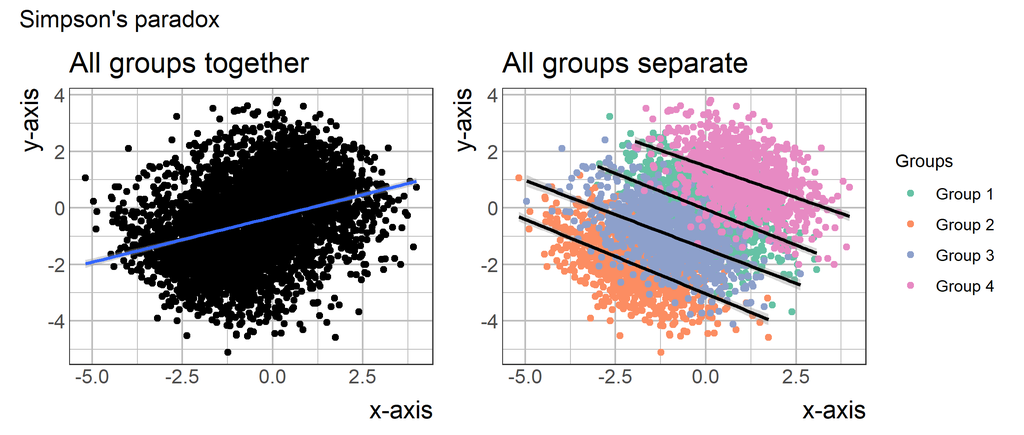

Figure 1

Here $x$ appears to have a positive correlation with $y$, but the opposite is true when you account for colour. $y$ is the explained variable, $x$ the observed explanatory variable, and colour the **lurking** explanatory variable.

## Simpson’s paradox

- Simpson’s paradox usually involves three variables:
  1. the response variable ($y$),
  2. the explanatory variable ($x$),
  3. a **lurking** variable ($z$).
- If the association between the response variable and the explanatory variable **changes direction** when you account for the lurking variable, you have got a Simpson’s paradox.

## The numbers, pooled and split

```r
# UCBAdmissions ships with R: the six largest departments, fall 1973.
round(100 * prop.table(margin.table(UCBAdmissions, c(1, 2)), 2), 1)
```

```
#>           Gender
#> Admit      Male Female
#>   Admitted 44.5   30.4
#>   Rejected 55.5   69.6
```

```r
round(100 * apply(UCBAdmissions, 3, function(d) prop.table(d, 2)["Admitted", ]), 1)
```

```
#>         Dept
#> Admit       A  B    C    D    E   F
#>   Male   62.1 63 36.9 33.1 27.7 5.9
#>   Female 82.4 68 34.1 34.9 23.9 7.0
```

Pooled, men are admitted at a higher rate. Split by department, women do as well or better in four of the six.

## UC Berkeley example

- The two observed variables were **Gender** and **Admission**, and the lurking variable was **Department**.
- The effect reverses when we break down by the department!
- The research paper by Bickel et al. concluded that women tended to apply to competitive departments with low rates of admission even among qualified applicants (such as in the English Department), whereas men tended to apply to less-competitive departments with high rates of admission among the qualified applicants (such as in engineering and chemistry).

## Another example

- Real-life example from medical studies.
- The table below shows the success rates and numbers of treatments for both small and large kidney stones, with two treatment procedures: Treatment A and Treatment B. The numbers in parentheses indicate the number of success cases over the total size of the group.

|  | Treatment A | Treatment B |
| --- | --- | --- |
| Small stones | **93% (81/87)** | 87% (234/270) |
| Large stones | **73% (192/263)** | 69% (55/80) |
| Both | 78% (273/350) | **83% (289/350)** |

- Treatment A is more effective when used on small stones, and also when used on large stones, yet treatment B is more effective when considering both sizes at the same time.
- The “lurking” variable (or confounding variable) is the **severity of the case** — the doctors’ tendency to favour B for less severe cases — which was not previously known to be important until its effects were included.

## Kidney stones in R

```r
stones <- data.frame(
  stone     = c("Small", "Small", "Large", "Large"),
  treatment = c("A", "B", "A", "B"),
  success   = c(81, 234, 192, 55),
  total     = c(87, 270, 263, 80)
)
stones$rate <- round(100 * stones$success / stones$total, 1)
stones
```

```
#>   stone treatment success total rate
#> 1 Small         A      81    87 93.1
#> 2 Small         B     234   270 86.7
#> 3 Large         A     192   263 73.0
#> 4 Large         B      55    80 68.8
```

```r
# pooled over stone size
with(stones, round(100 * tapply(success, treatment, sum) /
                         tapply(total,   treatment, sum), 1))
```

```
#>    A    B
#> 78.0 82.6
```

## Importance

- Simpson’s paradox often fools us when we want to compare performances.
- The last example shows why Simpson’s paradox matters. It would be dangerous if doctors prescribed ineffective or inferior treatments based on aggregate data.
- Another famous example shows that Wisconsin beats Texas on elementary school test scores overall, but if you break down by ethnic group, Texas almost always does better.
- Again, this shows the importance of understanding counter-intuitive results in statistics. A wrong conclusion could lead to a wild goose chase or a waste of public funds.
- Reference: http://educationnext.org/are-wisconsin-schools-better-than-those-in-texas/

# Exact test

## A note before we start

This section involves a little bit of discrete probability calculation — in particular, we will need the **hypergeometric distribution**.

## Fisher’s exact test

- The chi-square test works well when the expected cell counts are moderately large.
- If sample sizes are small, the $P$-values cannot be trusted.
- In such cases we need to rely on *exact* rather than large-sample approximations (asymptotic tests).
- One such method is **Fisher’s exact test**.

## Set-up for Fisher’s exact test

Fisher’s exact test is valid when:

1. the row totals $n_{i\cdot}$ and the column totals $n_{\cdot j}$ are both fixed by design of the study;<sup>1</sup>
2. the usual chi-square is not valid — e.g. when we have a small sample size $N$, and more than 20% of cells have expected cell counts less than 5, and no expected cell count is less than 1.
- However, keep in mind that $P$-values from exact tests are **conservative**.
- Still, in many situations Fisher’s exact test is the only valid option.
[^2]: This doesn’t always happen.

## Famous experiment: Lady tasting tea<sup>1</sup>

*A Lady declares that by tasting a cup of tea made with milk she can discriminate whether the milk or the tea infusion was first added to the cup. We will consider the problem of designing an experiment by means of which this assertion can be tested.*

[^3]: *The Design of Experiments* (London, Oliver and Boyd, 260pp.), Sir R. A. Fisher.

## Lady tasting tea<sup>1</sup>

- Our experiment consists in mixing eight cups of tea, **four in one way and four in the other**, and presenting them to the subject for judgment **in a random order**.
- The subject has been told in advance of what the test will consist, namely that she will be asked to taste eight cups, that these shall be four of each kind, and that they shall be presented to her in a random order, **that is in an order not determined arbitrarily by human choice, but by the actual manipulation of the physical apparatus used in games of chance, cards, dice, roulettes, etc.**, …
- Her task is to divide the 8 cups into two sets of 4, agreeing, if possible, with the treatments received.
[^4]: *The Design of Experiments*, Sir R. A. Fisher.

## Lady tasting tea: combinatorial argument

1. There are $\binom{8}{4} = 70$ ways to distribute the four “milk-first” cups among the 8.
2. Under the null hypothesis that the lady cannot taste any difference, her labeling of the 8 cups — 4 milk-first and 4 tea-infusion-first — can be thought of as fixed in advance.
3. The probability that her labeling exactly matches the truth is thus $1/70$.
4. A test that rejects the null hypothesis only when she matches all 8 cups has significance level $1/70 = 1.4\%$.

## Lady tasting tea: combinatorial argument (contd.)

1. If she misses one cup, she must in fact miss at least two, because she will have mislabeled a milk-first as tea-first, and vice versa.
2. The possible numbers of “hits” are 0, 2, 4, 6, and 8.
3. To get 6 hits, she must label as milk-first three of the four true milk-first cups, and must mislabel as milk-first one of the four tea-first cups.
4. The number of arrangements that give exactly 6 hits is thus $\binom{4}{3}\times\binom{4}{1} = 16$.
5. Thus if we reject the null hypothesis when she correctly identifies 6 of the 8 cups or all 8 of the 8 cups, the significance level of the test is $(16+1)/70 = 24.3\%$.
6. Such good performance is pretty likely to occur by chance — **about as likely as getting two heads in two tosses of a fair coin** — even if the lady and the tea are in different parlors.

## The real data

- What really happened?
- In a summer tea-party in Cambridge, England, a lady claimed to be able to discern, by taste alone, whether a cup of tea with milk had the tea poured first or the milk poured first.
- An experiment was performed by Sir R. A. Fisher himself, then and there, to see if her claim is valid. The outcomes were as follows:

Table 9

```r
tea <- matrix(
  c(3, 1,
    1, 3),
  nrow = 2, byrow = TRUE,
  dimnames = list(`Poured first` = c("Tea", "Milk"),
                  `Lady says`    = c("Tea first", "Milk first"))
)
tea
```

```
#>             Lady says
#> Poured first Tea first Milk first
#>         Tea          3          1
#>         Milk         1          3
```

## Hypergeometric distribution

- The hypergeometric distribution describes the probability that in a sample of $n$ distinctive units drawn from a finite population of size $N$ **without replacement**, there are $k$ successes.
- Consider that you draw $n$ balls from a box with red and blue balls, where there is a total of $N$ balls. There are a total of $D$ red balls in the box. What’s the probability that we will get exactly $k$ red balls?

|  | draw | no draw | total |
| --- | --- | --- | --- |
| red | $k$ | ? | $\mathbf{D}$ |
| blue | ? | ? | ? |
| total | $\mathbf{n}$ | ? | $\mathbf{N}$ |

$$P(k \mid n, D, N) = \frac{\binom{D}{k}\binom{N-D}{n-k}}{\binom{N}{n}},
\qquad k = 0, 1, 2, \ldots, n$$

## Hypergeometric distribution and $P$-value

Filling in the cells that the margins determine:

|  | draw | no draw | total |
| --- | --- | --- | --- |
| red | $k$ | $D-k$ | $\mathbf{D}$ |
| blue | $n-k$ | $N+k-n-D$ | $N-D$ |
| total | $\mathbf{n}$ | $N-n$ | $\mathbf{N}$ |

$$P(k \mid n, D, N) = \frac{\binom{D}{k}\binom{N-D}{n-k}}{\binom{N}{n}},
\qquad k = 0, 1, 2, \ldots, n$$

## $P$-value

|  | draw | no draw | total |
| --- | --- | --- | --- |
| red | $k$ | $D-k$ | $D$ |
| blue | $n-k$ | $N+k-n-D$ | $N-D$ |
| total | $n$ | $N-n$ | $N$ |

- This is exactly like Fisher’s lady tasting tea example: fixed column totals and margins.
- Recall that a $P$-value is the probability of getting a result as extreme or more extreme than the event you actually did observe, if $H_0$ is true.
- In this example, the $P$-value is $P(k \ge t_0)$, where $t_0$ is the observed value of $k$ — in this case 3.

## Calculation

1. Under $H_0$: “the lady has no discerning ability”, i.e. the four cups she calls “tea first” are a random sample from the eight.
2. If she selects four at random, the probability that three of these four are actually “tea first” comes from the hypergeometric distribution. Here $N = 8$, $D = 4$, $n = 4$:
   $$P(k=3) = \frac{\binom{4}{3}\binom{4}{1}}{\binom{8}{4}} = \frac{16}{70} = 0.229$$
3. The only result more extreme is that the lady selects all four of the cups that are truly “tea first”:
   $$P(k=4) = \frac{\binom{4}{4}\binom{4}{0}}{\binom{8}{4}} = \frac{1}{70} = 0.014$$
4. The $P$-value is $0.229 + 0.014 = 0.243$, which is only weak evidence against the null. There is not enough evidence to reject our hypothesis that the lady is purely guessing.

## The calculation in R

`dhyper(k, D, N - D, n)` gives the whole null distribution of the $(1,1)$ cell:

```r
k <- 0:4
data.frame(k = k, prob = round(dhyper(k, m = 4, n = 4, k = 4), 4))
```

```
#>   k   prob
#> 1 0 0.0143
#> 2 1 0.2286
#> 3 2 0.5143
#> 4 3 0.2286
#> 5 4 0.0143
```

```r
sum(dhyper(3:4, m = 4, n = 4, k = 4))   # P(k >= 3)
```

```
#> [1] 0.2428571
```

## Fisher’s exact test in R

```r
fisher.test(tea, alternative = "greater")
```

```
#>
#>  Fisher's Exact Test for Count Data
#>
#> data:  tea
#> p-value = 0.2429
#> alternative hypothesis: true odds ratio is greater than 1
#> 95 percent confidence interval:
#>  0.3135693       Inf
#> sample estimates:
#> odds ratio
#>   6.408309
```

The one-sided $P$-value is $17/70 = 0.243$, exactly the combinatorial answer.

## Another way

- The basic idea behind exact tests is that they **enumerate all possible tables that have the same margins**, e.g. row sums and column sums.
- Then, to compute the relevant statistic, e.g. $\chi^2$, you look for all tables where the values are more extreme than the one you have observed. The $P$-value is the sum of the probabilities of all such “more extreme” tables.

```r
# Every 2x2 table with all margins equal to 4, indexed by the (1,1) cell.
for (k in 0:4) {
  cat("k =", k, ":  [", k, 4 - k, "/", 4 - k, k, "]   P =",
      round(dhyper(k, 4, 4, 4), 4), "\n")
}
```

```
#> k = 0 :  [ 0 4 / 4 0 ]   P = 0.0143
#> k = 1 :  [ 1 3 / 3 1 ]   P = 0.2286
#> k = 2 :  [ 2 2 / 2 2 ]   P = 0.5143
#> k = 3 :  [ 3 1 / 1 3 ]   P = 0.2286
#> k = 4 :  [ 4 0 / 0 4 ]   P = 0.0143
```

## Computing<sup>1</sup>

- The key here is that in the set of tables with the same margins, once you know the value in one cell, you know the rest of the cells. Therefore, to find the probability of observing a table, we need to find the probability of only one cell in the table (rather than the probabilities of four cells). Typically we use the value of cell $(1,1)$.
- Under the null hypothesis of independence, the probability distribution of that one cell (e.g. $n_{11}$) is hypergeometric, as discussed before.
- Note that these tests can be **conservative**. Because of the discreteness of the data, and the small number of possible realizations, e.g. tables, the Type I error rate will be smaller than the intended one (e.g. $\alpha = 0.05$).
[^5]: Adapted from a University of Sheffield tutorial on Fisher’s exact test.

## Alternative approaches

There are other experiments we might construct to test this hypothesis. Lindley (1984, *A Bayesian Lady Tasting Tea*) lists two, which he attributes to Neyman:

1. Present the lady with $n$ **pairs** of cups of tea with milk, where one cup in each pair (determined randomly) has milk added first and one has tea added first. Tell the lady that each pair has one of each kind of cup; ask her to identify which member of each pair had the milk added first. Count the number of pairs she categorizes correctly.
2. Present the lady with $n$ cups of tea with milk, each of which has probability $1/2$ of having the milk added first and probability $1/2$ of having the tea added first. Do **not** tell the lady how many of each sort of cup there are. Ask her to identify for each cup whether milk or tea was added first. Count the number of cups she categorizes correctly.

Each design implies a different null distribution — binomial rather than hypergeometric — and so a different test.

## Summary

| Situation | Test | R |
| --- | --- | --- |
| $r \times k$ table, large expected counts | chi-square for association | `chisq.test()` |
| $K \times 2$ table | equality of $K$ proportions | `prop.test()` |
| Strength of association | $\phi$, $C$, Cramér’s $V$ | from $Q$ and $N$ |
| Paired $2 \times 2$ | McNemar | `mcnemar.test()` |
| Small counts, fixed margins | Fisher’s exact | `fisher.test()` |
| Three variables, reversal | Simpson’s paradox | stratify before pooling |